# Differential accessibility analysis

05 April 2019

We have ATAC-seq data for 50 good-quality samples, comprising the last three generated somites of mouse embryos at six different developmental stages.

```r
## metadata
meta <- read.table(paste0(dir, "ATAC-seq/data/metadata_ATACseq_GQ.tsv"), stringsAsFactors = FALSE, header = TRUE)
meta <- meta[meta$QCpass==1,]

## data
filtered.data <- readRDS(paste0(dir, "ATAC-seq/results/03_windowCounts_filteredWindows.Rds"))
```

We have defined a set of peaks representing regions of open chromatin, and computed the sequencing data counts for 150bp windows covering such loci. We have used a trended-normalisation approach to remove systematic biases. On this normalised dataset, the major source of variation was still strongly correlated to the fraction of reads in peaks (FRiP) for each sample. Thus, we have tried two approaches to capture such variation:

- Surrogate variable analysis: identifies one surrogate variable that is strongly correlated to FRiP and thus should be able to remove this effect.
- PCA on the residuals of the model containing the somite-stage information: the first few PCs are correlated to FRiP and consideration of the first 18 components cleans up the data nicely.

As a baseline, we will perform the differential analysis without any correction, and assuming the normalisation has successfully removed technical biases. We can then compare these results to those obtained when incorporating the SVA or PCA covariates, to see if they are indeed removing technical noise or instead are capturing biological signal.

### Differential accessibility analysis

We can test for differences between the somite trios and between stages.

We use `edgeR` to perform the differential testing. We first estimate the dispersion and fit the design containing the interaction of somite and stage.

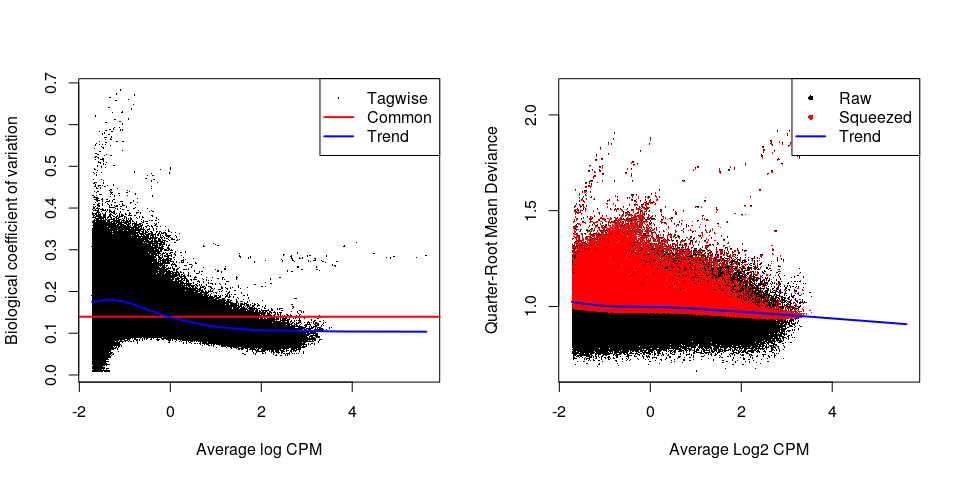

```r
## edgeR object
y <- asDGEList(filtered.data)

## design
meta$group <- factor(paste(meta$stage, meta$somite, sep="."))
design <- model.matrix(~0+group, meta)
colnames(design) <- paste0("stage",levels(meta$group))

## dispersion
y <- estimateDisp(y, design)
par(mfrow=c(1,2))
plotBCV(y)

## fit model
fit <- glmQLFit(y, design, robust=TRUE)
plotQLDisp(fit)
```

```r
# summary(fit$df.prior)

saveRDS(y, file=paste0(dir, "ATAC-seq/results/04.1_edgeRobject.Rds"))
```

##### Differences across somite trios

We can now compare the chromatin accessibility as somites differentiate (somite I vs II vs III). First, we perform the comparison for each stage. We are underpowered in several stages, where we don’t have replicates for a particular somite-stage combination.

```r
table(meta$stage, meta$somite)
```

```
##
##      SI SII SIII
##   8   2   2    2
##   18  3   4    3
##   21  2   4    1
##   25  4   4    3
##   27  3   1    1
##   35  5   4    2
```

We definitely exclude stage27 from the analysis. For all other stages, we define all three pairwise comparisons, and test them all together with an anova-like test.

```r
my.contrasts <- makeContrasts(stage8.IIvsI=stage8.SII-stage8.SI, stage8.IIIvsI=stage8.SIII-stage8.SI,
                              stage8.IIIvsII=stage8.SIII-stage8.SII,
                              stage18.IIvsI=stage18.SII-stage18.SI, stage18.IIIvsI=stage18.SIII-stage18.SI,
                              stage18.IIIvsII=stage18.SIII-stage18.SII,
                              stage21.IIvsI=stage21.SII-stage21.SI, stage21.IIIvsI=stage21.SIII-stage21.SI,
                              stage21.IIIvsII=stage21.SIII-stage21.SII,
                              stage25.IIvsI=stage25.SII-stage25.SI, stage25.IIIvsI=stage25.SIII-stage25.SI,
                              stage25.IIIvsII=stage25.SIII-stage25.SII,
                              stage35.IIvsI=stage35.SII-stage35.SI, stage35.IIIvsI=stage35.SIII-stage35.SI,
                              stage35.IIIvsII=stage35.SIII-stage35.SII, levels=design)

## test
stage8 <- glmQLFTest(fit, contrast = my.contrasts[,1:3])
stage18 <- glmQLFTest(fit, contrast = my.contrasts[,4:6])
stage21 <- glmQLFTest(fit, contrast = my.contrasts[,7:9])
stage25 <- glmQLFTest(fit, contrast = my.contrasts[,10:12])
stage35 <- glmQLFTest(fit, contrast = my.contrasts[,13:15])
```

Not surprisingly, there are no significant findings for most of the stages. Only the comparison for stage 25 returns a significant number of differential regions, probably because of the larger number of replicates and higher sample quality (see `02_qualityControl.md`).

```r
merged <- mergeWindows(rowRanges(filtered.data), tol=150, max.width = 1500)

somiteTrios.perStage <- list()
somiteTrios.perStage[['stage8']] <- merged$region
mcols(somiteTrios.perStage[['stage8']]) <- combineTests(merged$id, stage8$table)
somiteTrios.perStage[['stage18']] <- merged$region
mcols(somiteTrios.perStage[['stage18']]) <- combineTests(merged$id, stage18$table)
somiteTrios.perStage[['stage21']] <- merged$region
mcols(somiteTrios.perStage[['stage21']]) <- combineTests(merged$id, stage21$table)
somiteTrios.perStage[['stage25']] <- merged$region
mcols(somiteTrios.perStage[['stage25']]) <- combineTests(merged$id, stage25$table)
somiteTrios.perStage[['stage35']] <- merged$region
mcols(somiteTrios.perStage[['stage35']]) <- combineTests(merged$id, stage35$table)
saveRDS(somiteTrios.perStage, paste0(dir, "ATAC-seq/results/04.1_diffAccessibility_somiteTrios_perStage.Rds"))

df <- t(data.frame(stage8=sum(mcols(somiteTrios.perStage[['stage8']])$FDR <= 0.05),
           stage18=sum(mcols(somiteTrios.perStage[['stage18']])$FDR <= 0.05),
           stage21=sum(mcols(somiteTrios.perStage[['stage21']])$FDR <= 0.05),
           stage25=sum(mcols(somiteTrios.perStage[['stage25']])$FDR <= 0.05),
           stage35=sum(mcols(somiteTrios.perStage[['stage35']])$FDR <= 0.05)))
colnames(df) <- "nDA"
df
```

```
##         nDA
## stage8    1
## stage18   0
## stage21   0
## stage25 266
## stage35   7
```

To increase power we combine samples from all stages and test the average of each somite. We will loose any changes that are stage-specific but should recover more of the consistent changes:

```r
my.contrasts <- makeContrasts(
  somiteIIvsI = (stage8.SII + stage18.SII + stage21.SII + stage25.SII + stage27.SII + stage35.SII)/6 - (stage8.SI + stage18.SI + stage21.SI + stage25.SI + stage27.SI + stage35.SI)/6,
  somiteIIIvsI = (stage8.SIII + stage18.SIII + stage21.SIII + stage25.SIII + stage27.SIII + stage35.SIII)/6 - (stage8.SI + stage18.SI + stage21.SI + stage25.SI + stage27.SI + stage35.SI)/6,
  somiteIIIvsII = (stage8.SIII + stage18.SIII + stage21.SIII + stage25.SIII + stage27.SIII + stage35.SIII)/6 - (stage8.SII + stage18.SII + stage21.SII + stage25.SII + stage27.SII + stage35.SII)/6,
  levels=design)

somiteIIvsI.all <- glmQLFTest(fit, contrast = my.contrasts[,"somiteIIvsI"])
somiteIIIvsI.all <- glmQLFTest(fit, contrast = my.contrasts[,"somiteIIIvsI"])
somiteIIIvsII.all <- glmQLFTest(fit, contrast = my.contrasts[,"somiteIIIvsII"])

## data.frames
somiteTrios.average <- list()

somiteTrios.average[['somiteIIvsI']] <- merged$region
mcols(somiteTrios.average[['somiteIIvsI']]) <- combineTests(merged$id, somiteIIvsI.all$table)
somiteTrios.average[['somiteIIvsI']] <- somiteTrios.average[['somiteIIvsI']][order(somiteTrios.average[['somiteIIvsI']]$FDR)]
somiteTrios.average[['somiteIIIvsI']] <- merged$region
mcols(somiteTrios.average[['somiteIIIvsI']]) <- combineTests(merged$id, somiteIIIvsI.all$table)
somiteTrios.average[['somiteIIIvsI']] <- somiteTrios.average[['somiteIIIvsI']][order(somiteTrios.average[['somiteIIIvsI']]$FDR)]
somiteTrios.average[['somiteIIIvsII']] <- merged$region
mcols(somiteTrios.average[['somiteIIIvsII']]) <- combineTests(merged$id, somiteIIIvsII.all$table)
somiteTrios.average[['somiteIIIvsII']] <- somiteTrios.average[['somiteIIIvsII']][order(somiteTrios.average[['somiteIIIvsII']]$FDR)]

saveRDS(somiteTrios.average, paste0(dir, "ATAC-seq/results/04.1_diffAccessibility_somiteTrios_average.Rds"))

data.frame(somiteIvsII=sum(mcols(somiteTrios.average[['somiteIIvsI']])$FDR <= 0.05),
           somiteIvsIII=sum(mcols(somiteTrios.average[['somiteIIIvsI']])$FDR <= 0.05),
           somiteIIvsIII=sum(mcols(somiteTrios.average[['somiteIIIvsII']])$FDR <= 0.05))
```

```
##   somiteIvsII somiteIvsIII somiteIIvsIII
## 1           3          909             0
```

##### Differences across developmental stages

Now, we can also test for changes across development. First, we test all pairwise comparisons between stages on a per-somite basis.

```r
my.contrasts <- makeContrasts(stage8vs18 = stage18.SI - stage8.SI, stage8vs21 = stage21.SI - stage8.SI,
                              stage8vs25 = stage25.SI - stage8.SI, stage8vs27 = stage27.SI - stage8.SI,
                              stage8vs35 = stage35.SI - stage8.SI,
                              stage18vs21 = stage21.SI - stage18.SI, stage18vs25 = stage25.SI - stage18.SI,
                              stage18vs27 = stage27.SI - stage18.SI, stage18vs35 = stage35.SI - stage18.SI,
                              stage21vs25 = stage25.SI - stage21.SI, stage21vs27 = stage27.SI - stage21.SI,
                              stage21vs35 = stage35.SI - stage21.SI,
                              stage25vs27 = stage27.SI - stage25.SI,  stage25vs35 = stage35.SI - stage25.SI,
                              stage27vs35 = stage35.SI - stage27.SI, levels=design)

somiteI <- glmQLFTest(fit, contrast = my.contrasts)

my.contrasts <- makeContrasts(stage8vs18 = stage18.SII - stage8.SII, stage8vs21 = stage21.SII - stage8.SII,
                              stage8vs25 = stage25.SII - stage8.SII, stage8vs27 = stage27.SII - stage8.SII,
                              stage8vs35 = stage35.SII - stage8.SII,
                              stage18vs21 = stage21.SII - stage18.SII, stage18vs25 = stage25.SII - stage18.SII,
                              stage18vs27 = stage27.SII - stage18.SII, stage18vs35 = stage35.SII - stage18.SII,
                              stage21vs25 = stage25.SII - stage21.SII, stage21vs27 = stage27.SII - stage21.SII,
                              stage21vs35 = stage35.SII - stage21.SII,
                              stage25vs27 = stage27.SII - stage25.SII,  stage25vs35 = stage35.SII - stage25.SII,
                              stage27vs35 = stage35.SII - stage27.SII, levels=design)
somiteII <- glmQLFTest(fit, contrast = my.contrasts)

my.contrasts <- makeContrasts(stage8vs18 = stage18.SIII - stage8.SIII, stage8vs21 = stage21.SIII - stage8.SIII,
                              stage8vs25 = stage25.SIII - stage8.SIII, stage8vs27 = stage27.SIII - stage8.SIII,
                              stage8vs35 = stage35.SIII - stage8.SIII,
                              stage18vs21 = stage21.SIII - stage18.SIII, stage18vs25 = stage25.SIII - stage18.SIII,
                              stage18vs27 = stage27.SIII - stage18.SIII, stage18vs35 = stage35.SIII - stage18.SIII,
                              stage21vs25 = stage25.SIII - stage21.SIII, stage21vs27 = stage27.SIII - stage21.SIII,
                              stage21vs35 = stage35.SIII - stage21.SIII,
                              stage25vs27 = stage27.SIII - stage25.SIII, stage25vs35 = stage35.SIII - stage25.SIII,
                              stage27vs35 = stage35.SIII - stage27.SIII, levels=design)
somiteIII <- glmQLFTest(fit, contrast = my.contrasts)
```

```r
stage.perSomite <- list()
stage.perSomite[['somiteI']] <- merged$region
mcols(stage.perSomite[['somiteI']]) <- combineTests(merged$id, somiteI$table)
stage.perSomite[['somiteII']] <- merged$region
mcols(stage.perSomite[['somiteII']]) <- combineTests(merged$id, somiteII$table)
stage.perSomite[['somiteIII']] <- merged$region
mcols(stage.perSomite[['somiteIII']]) <- combineTests(merged$id, somiteIII$table)
saveRDS(stage.perSomite, paste0(dir, "ATAC-seq/results/04.1_diffAccessibility_stages_perSomite.Rds"))

df <- t(data.frame(somiteI=sum(mcols(stage.perSomite[['somiteI']])$FDR <= 0.05),
           somiteII=sum(mcols(stage.perSomite[['somiteII']])$FDR <= 0.05),
           somiteIII=sum(mcols(stage.perSomite[['somiteIII']])$FDR <= 0.05)))
colnames(df) <- "nDA"
df
```

```
##            nDA
## somiteI   4648
## somiteII  1427
## somiteIII 1601
```

Interestingly, there are plenty of regions that are significant in a somite-specific manner.

```r
p <- makeVennDiagram(list(somiteI=stage.perSomite[["somiteI"]][stage.perSomite[["somiteI"]]$FDR < 0.05,],
                          somiteII=stage.perSomite[["somiteII"]][stage.perSomite[["somiteII"]]$FDR < 0.05,],
                          somiteIII=stage.perSomite[["somiteIII"]][stage.perSomite[["somiteIII"]]$FDR < 0.05,]))
```

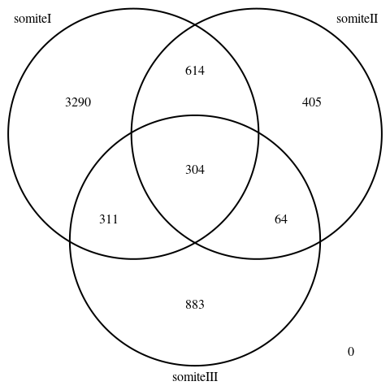

Now, we instead take the average of somites I, II and III. This should increase power for changes that are conserved across the AP axis, but driven by developmental progression.

```r
my.contrasts <- makeContrasts(stage8vs18 = (stage18.SIII+stage18.SII+stage18.SI)/3 - (stage8.SIII+stage8.SII+stage8.SI)/3,
                              stage8vs21 = (stage21.SIII+stage21.SII+stage21.SI)/3 - (stage8.SIII+stage8.SII+stage8.SI)/3,
                              stage8vs25 = (stage25.SIII+stage25.SII+stage25.SI)/3 - (stage8.SIII+stage8.SII+stage8.SI)/3,
                              stage8vs27 = (stage27.SIII+stage27.SII+stage27.SI)/3 - (stage8.SIII+stage8.SII+stage8.SI)/3,
                              stage8vs35 = (stage35.SIII+stage35.SII+stage35.SI)/3 - (stage8.SIII+stage8.SII+stage8.SI)/3,
                              stage18vs21 = (stage21.SIII+stage21.SII+stage21.SI)/3 - (stage18.SIII+stage18.SII+stage18.SI)/3,
                              stage18vs25 = (stage25.SIII+stage25.SII+stage25.SI)/3 - (stage18.SIII+stage18.SII+stage18.SI)/3,
                              stage18vs27 = (stage27.SIII+stage27.SII+stage27.SI)/3 - (stage18.SIII+stage18.SII+stage18.SI)/3,
                              stage18vs35 = (stage35.SIII+stage35.SII+stage35.SI)/3 - (stage18.SIII+stage18.SII+stage18.SI)/3,
                              stage21vs25 = (stage25.SIII+stage25.SII+stage25.SI)/3 - (stage21.SIII+stage21.SII+stage21.SI)/3,
                              stage21vs27 = (stage27.SIII+stage27.SII+stage27.SI)/3 - (stage21.SIII+stage21.SII+stage21.SI)/3,
                              stage21vs35 = (stage35.SIII+stage35.SII+stage35.SI)/3 - (stage21.SIII+stage21.SII+stage21.SI)/3,
                              stage25vs27 = (stage27.SIII+stage27.SII+stage27.SI)/3 - (stage25.SIII+stage25.SII+stage25.SI)/3,
                              stage25vs35 = (stage35.SIII+stage35.SII+stage35.SI)/3 - (stage25.SIII+stage25.SII+stage25.SI)/3,
                              stage27vs35 = (stage35.SIII+stage35.SII+stage35.SI)/3 - (stage27.SIII+stage27.SII+stage27.SI)/3, levels=design)

test <- glmQLFTest(fit, contrast = my.contrasts)
```

And we test against the null that none of the stages are different. Therefore, anything with an FDR of 5% or lower indicates a region of open chromatin that is differentially accessible between at least a pair of stages.

Nearly 20 thousand regions are differentially accessible across development.

```r
stage.average <- merged$region
mcols(stage.average) <- combineTests(merged$id, test$table)

summary(stage.average$FDR<0.05)
```

```
##    Mode   FALSE    TRUE
## logical  153336   19565
```

```r
saveRDS(stage.average, paste0(dir, "ATAC-seq/results/04.1_diffAccessibility_stages_average.Rds"))
```